# Graficar en R

### Definir colores

Los colores que R ocupa para colorear algo están definidos en `palette` y pueden cambiarse

```r
# Ver colores
palette()
```

```
## [1] "black"   "red"     "green3"  "blue"    "cyan"    "magenta" "yellow"
## [8] "gray"
```

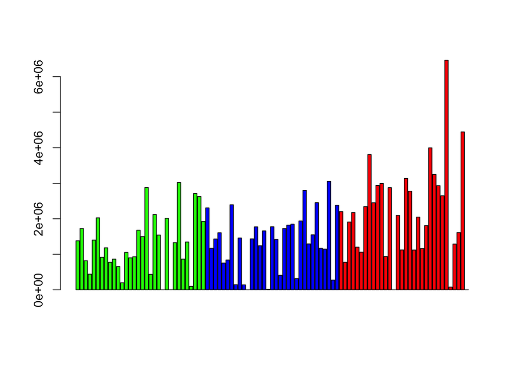

```r
# Cambiar colores
palette(c("green", "blue", "red"))

# volver a graficar
barplot(reads$nreads, col=reads$Library)
```

Además de manualmente, los colores se pueden definir via paletas predeterminadas:

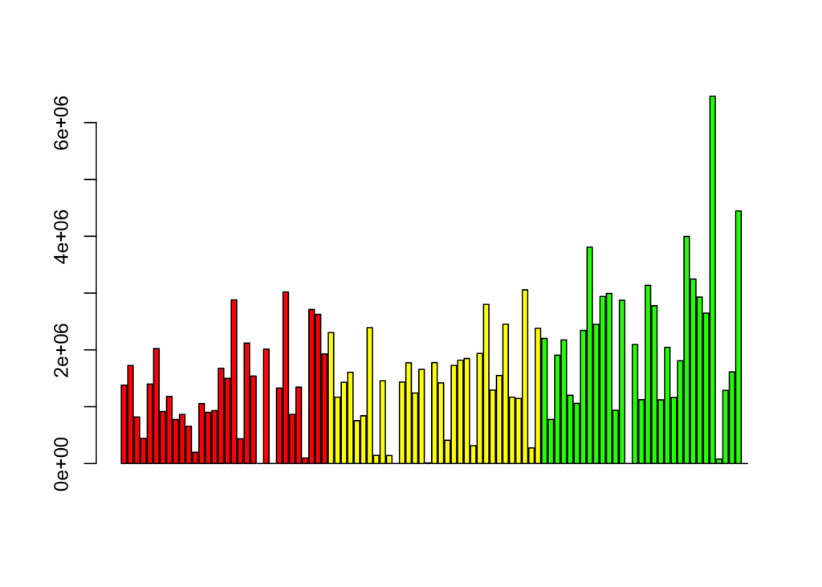

```r
# Cambiar palette a 6 colores del arcoiris
palette(rainbow(6))

# volver a graficar
barplot(reads$nreads, col=reads$Library)
```

Checa otras palettes parecidas a `rainbow` en [este link](http://www.r-bloggers.com/color-palettes-in-r/), y no te pierdas cómo nombrar muchos otros colores y utilizar otras paletas con más colores en la [R Color Reference Sheet](http://www.r-bloggers.com/r-color-reference-sheet/). Si necesitas generar muchos colores [I wanthue](http://tools.medialab.sciences-po.fr/iwanthue/) es lo que necesitas.

## ggplot2

Las gráficas que hemos visto hasta ahora pueden verse un poco feas de inicio y puede tomar un rato y mucho código arreglarlas a algo hermoso. `ggplot2` es un paquete que ahorra este trabajo y que ahora es ampliamente adoptado.

`ggplot2` construye gráficas “definiendo sus componentes paso a paso”.

Para poder usar `ggplot2` se requiere que la data.frame esté en **formato largo**, esto se puede hacer con la función `gather` de `tidyr`. Puedes revisar [esta referencia para detalles de cómo transformar a formato largo](http://www.cookbook-r.com/Manipulating_data/Converting_data_between_wide_and_long_format/).

Ejemplo de formato largo en el set (pre-incluido en R) iris:

```r
head(iris)
```

```
##   Sepal.Length Sepal.Width Petal.Length Petal.Width Species
## 1          5.1         3.5          1.4         0.2  setosa
## 2          4.9         3.0          1.4         0.2  setosa
## 3          4.7         3.2          1.3         0.2  setosa
## 4          4.6         3.1          1.5         0.2  setosa
## 5          5.0         3.6          1.4         0.2  setosa
## 6          5.4         3.9          1.7         0.4  setosa
```

```r
tail(iris)
```

```
##     Sepal.Length Sepal.Width Petal.Length Petal.Width   Species
## 145          6.7         3.3          5.7         2.5 virginica
## 146          6.7         3.0          5.2         2.3 virginica
## 147          6.3         2.5          5.0         1.9 virginica
## 148          6.5         3.0          5.2         2.0 virginica
## 149          6.2         3.4          5.4         2.3 virginica
## 150          5.9         3.0          5.1         1.8 virginica
```

**Términos importantes**:

**Ojo: Mucho mejor que ver la ayuda de cada función es ver la [Documentación online de ggplot2](http://docs.ggplot2.org/current/) y este [R Graphics Cookbook](http://www.cookbook-r.com/Graphs/)**

- `ggplot` la función principal donde se especifican el set de datos y las variables a graficar.
- **geoms** “objetos geométricos” (el tipo de gráfica en cierto modo):
- `geom_point()`
- `geom_bar()`
- `geom_density()`
- `geom_line()`
- `geom_area()`
- `geom_histogram()`
- **aes** los estéticos que pondremos: forma, transparencia (alpha), color, relleno, tipo de línea, etc.
- **scales** para especificar si los datos se graficarán de forma continua, discreta, logarítmica.
- **themes** para modificar los elementos de la gráfica no relacionados con los datos, como el tipo de letra y el color del fondo.

### Ejemplos:

#### Gráficas de dispersión

```r
# Cargar ggplot2
library(ggplot2)

# Examinar datos pre-cargados
head(iris)
```

```
##   Sepal.Length Sepal.Width Petal.Length Petal.Width Species
## 1          5.1         3.5          1.4         0.2  setosa
## 2          4.9         3.0          1.4         0.2  setosa
## 3          4.7         3.2          1.3         0.2  setosa
## 4          4.6         3.1          1.5         0.2  setosa
## 5          5.0         3.6          1.4         0.2  setosa
## 6          5.4         3.9          1.7         0.4  setosa
```

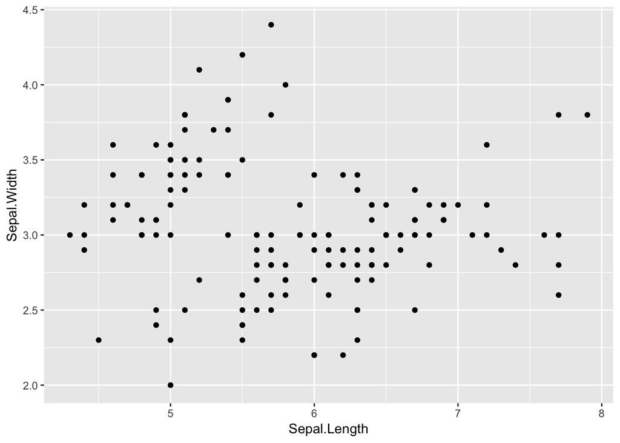

```r
# graficar
ggplot(data=iris, aes(x=Sepal.Length, y= Sepal.Width)) + geom_point()
```

**Pregunta:** ¿Qué hace el símbolo +? Nota que el código anterior tmb puede escribirse así:

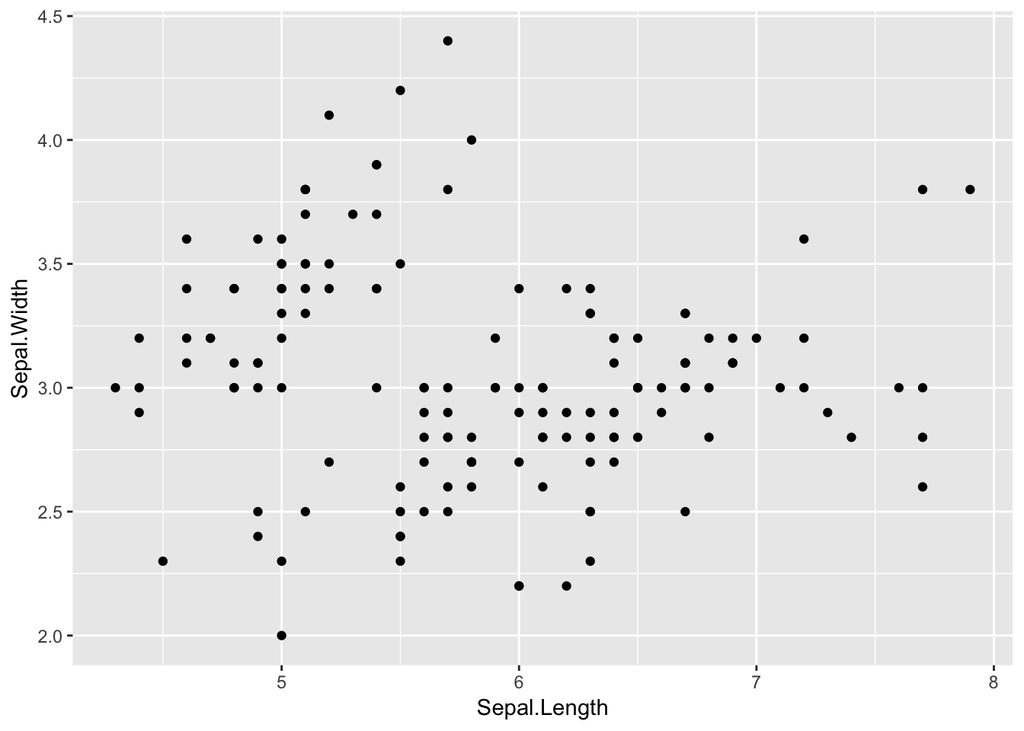

```r
myplot<-ggplot(data=iris, aes(x=Sepal.Length, y= Sepal.Width))

myplot + geom_point()
```

Los colores y formas se cambian en **aes**:

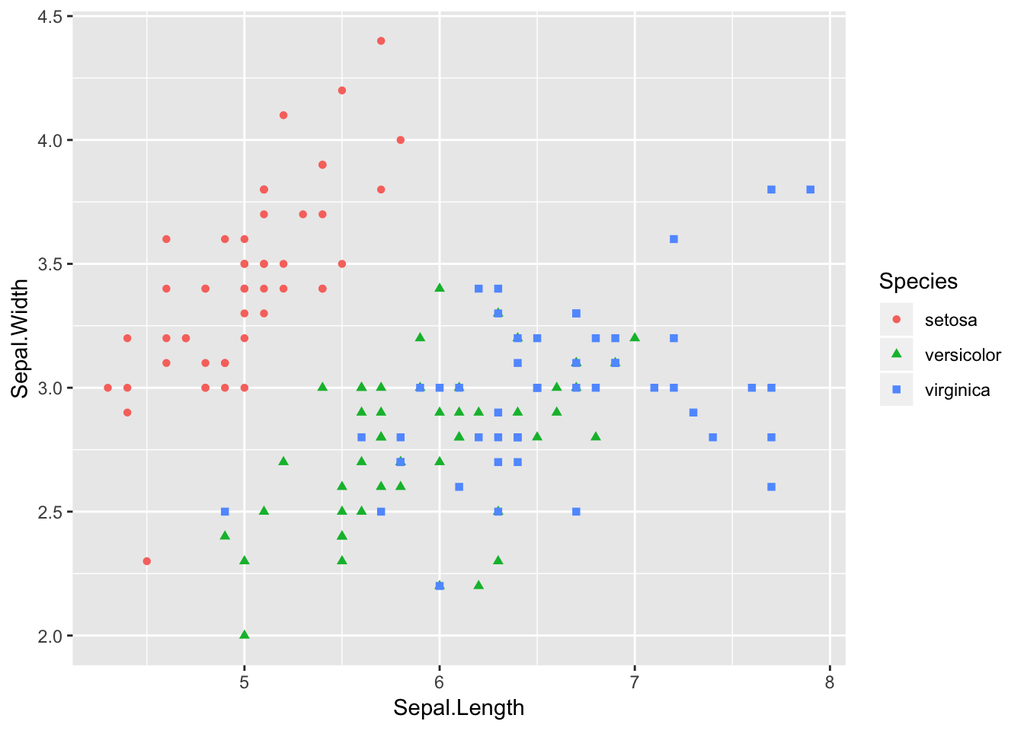

```r
ggplot(data=iris, aes(x=Sepal.Length, y= Sepal.Width, color= Species, shape=Species)) + geom_point()
```

Ya sea en el aes de la función inicial o dentro de los geoms (Nota que el tamaño no es un aes, sino un argumento de geom_point)

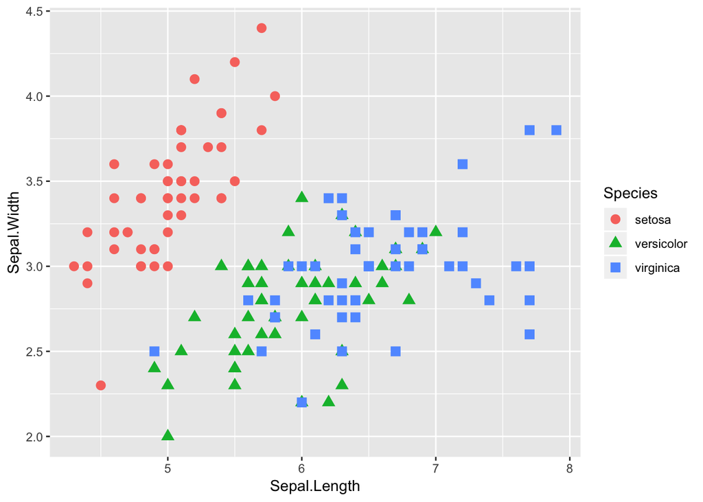

```r
ggplot(data=iris, aes(x=Sepal.Length, y= Sepal.Width)) +
    geom_point(aes(color= Species, shape=Species), size=3)
```

Aveces queremos graficar en páneles separados la misma info para diferentes tratamientos o especies. Por ejemplo:

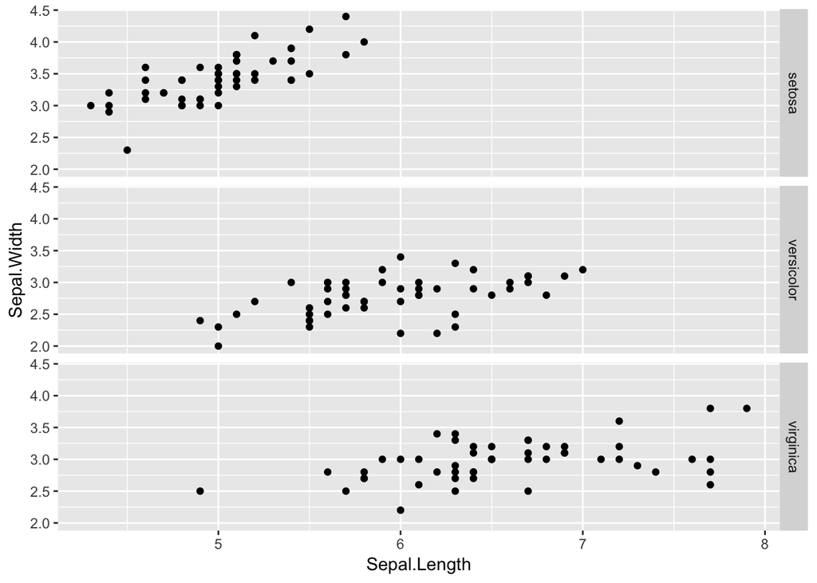

```r
ggplot(data=iris, aes(x=Sepal.Length, y= Sepal.Width)) +
  geom_point() +
  facet_grid(Species ~ .)
```

**Ejercicio** Pon color por especie a la gráfica anterior:

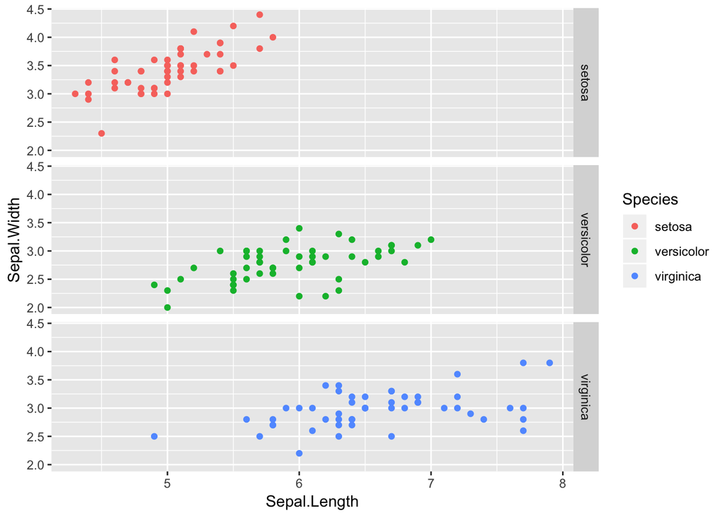

Cambiar los labels para que digan “Ancho de sépalo” y “Largo de sépalo”, respectivamente. Debe verse así:

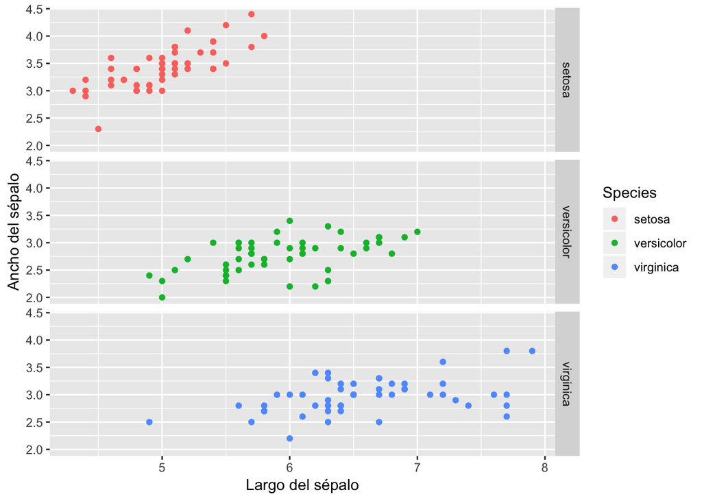

También podemos agregar el resultado de un modelo matemático, como una regresión lineal:

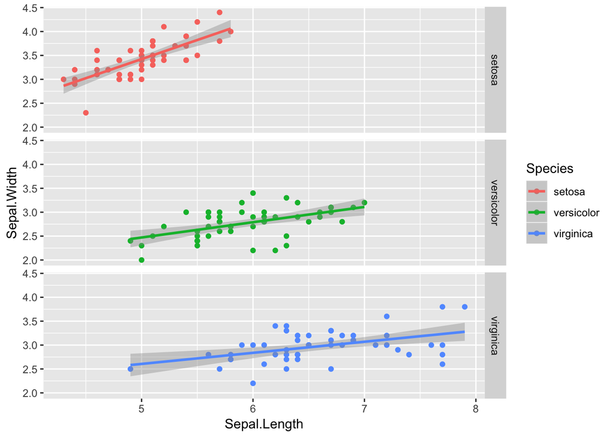

```r
ggplot(data=iris, aes(x=Sepal.Length, y= Sepal.Width, color=Species)) +
  geom_point() +
  facet_grid(Species ~ .) +
  geom_smooth(method="lm")
```

#### Barplot

En este tipo de gráficas la altura de las barras puede significar dos cosas:

- la **cuenta** (frecuencia) de casos de cada valor de x. Si quieres graficar esto utiliza `stat="bin"` en los argumentos de `geom_bar`.
- el **valor** de la columna en el set de datos. Si quieres graficar esto utiliza `stat="identity"` en los argumentos de `geom_bar`.

Ejemplo:

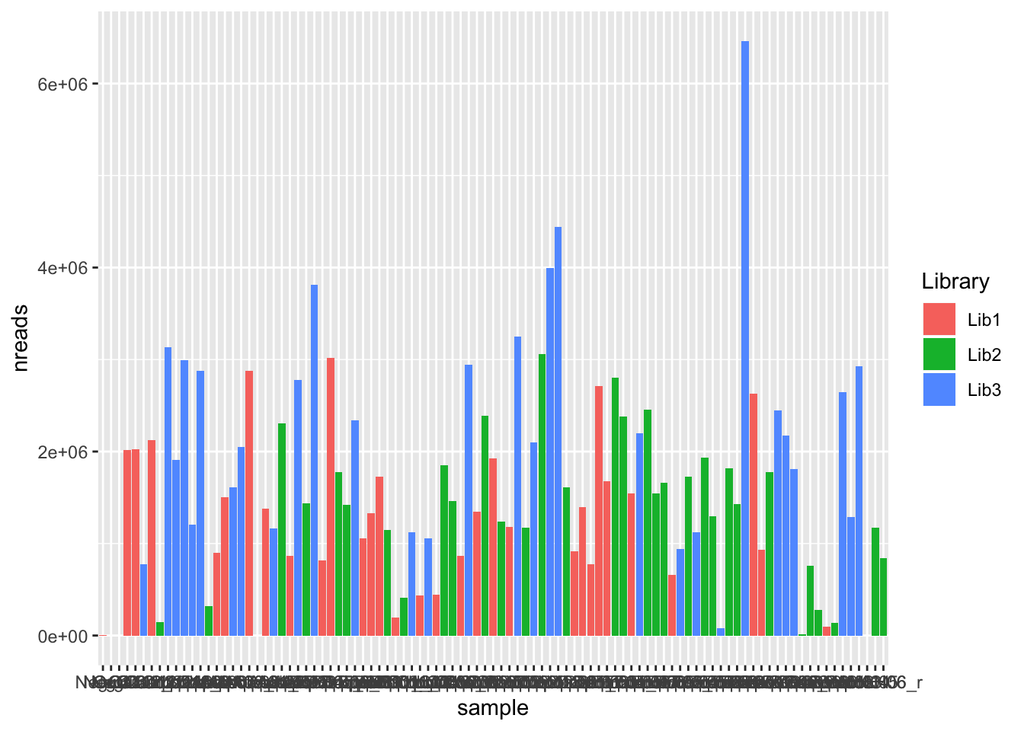

```r
# Cargar archivo
reads<-read.delim("Prac_R/ejemplos_generales/reads.txt")

# plot
p <- ggplot(data=reads, aes(x=sample, y=nreads, fill=Library)) +
  geom_bar(stat="identity")
p
```

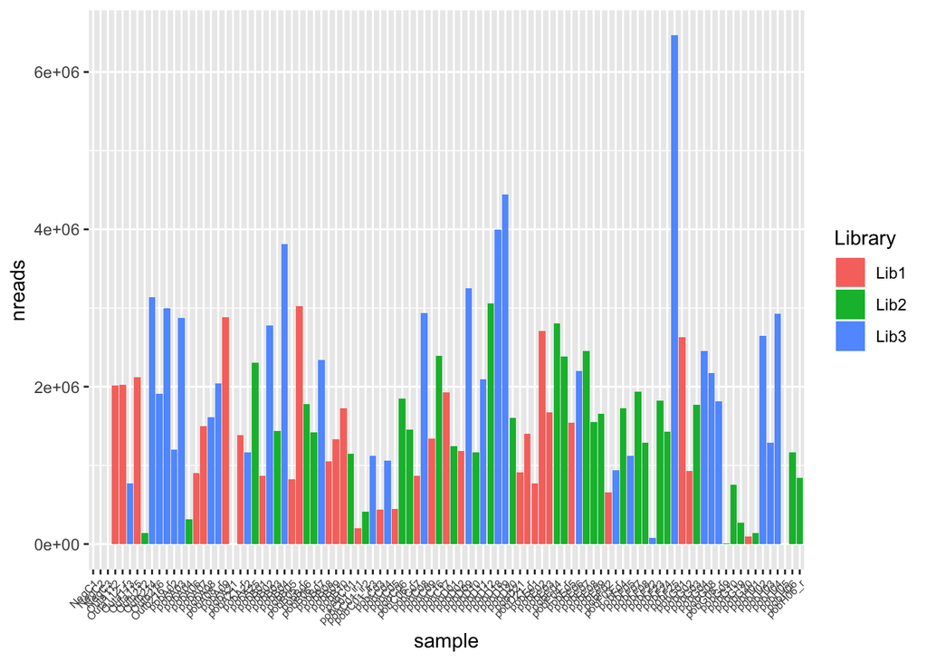

```r
# Rotar nombres muestras
p <- p +  theme(axis.text.x = element_text(angle = 45, hjust = 1, size=6))
p
```

La gráfica anterior no es igual a la que hicmos con `barplot` con los mismos datos ya que `ggplot2` grafica **en el orden de los levels**, en este caso:

```r
head(levels(reads$sample))
```

```
## [1] "NegC1"     "NegC2"     "NegC3"     "Outa112"   "Outa112_r" "Outa113"
```

Forma de solucionarlo:

```r
# Cambiar orden de levels:
reads$sample<-factor(reads$sample, levels = reads$sample[order(1:length(reads$sample))])
head(levels(reads$sample))
```

```
## [1] "pobA21_r"  "pobB10"    "pobB05"    "pobC05"    "pobD21_r"  "Outa112_r"
```

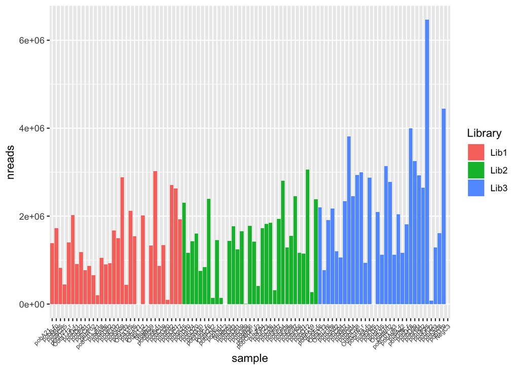

```r
# Graficar
# plot
p <- ggplot(data=reads, aes(x=sample, y=nreads, fill=Library)) + geom_bar(stat="identity")
p +  theme(axis.text.x = element_text(angle = 45, hjust = 1, size=6))
```

#### Boxplot

Siguiendo con los mismos datos anteriores:

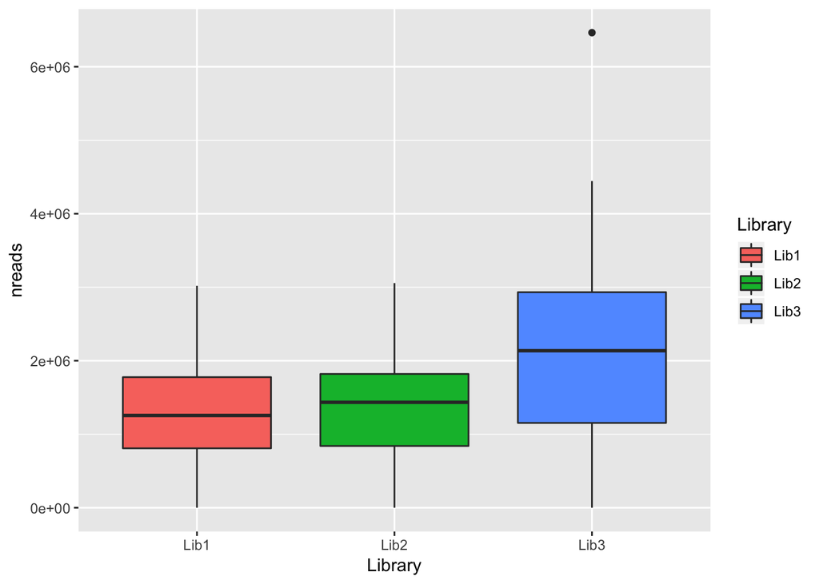

```r
# plot
p <- ggplot(data=reads, aes(x=Library, y=nreads, fill=Library)) + geom_boxplot()
p
```

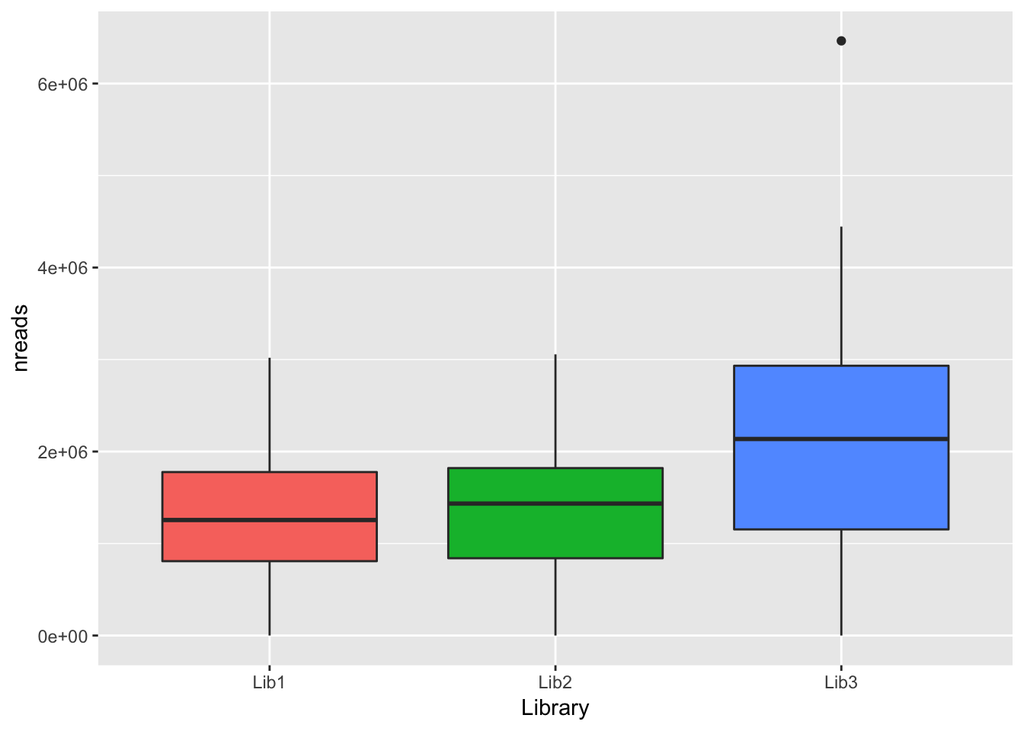

```r
# quitar leyenda
p + guides(fill=FALSE)
```

### Cambiar colores en ggplot

Al igual que en base, en ggplot es posible cambiar los colores manualmente o cambiando la paleta.

Recomiendo buscar más información y ejemplos en esta excelente guía [Cookbook-R colores en ggplot2](http://www.cookbook-r.com/Graphs/Colors_%28ggplot2%29/).

Ejemplos:

**Cambiar colores manualmente**

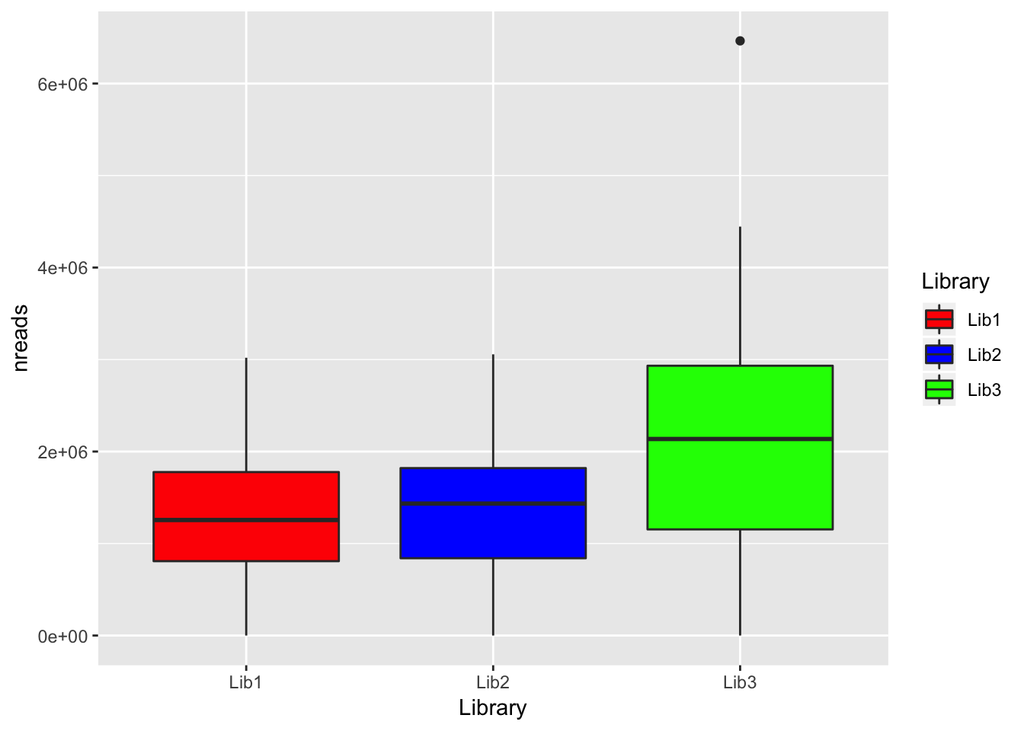

```r
# Crear paleta:
cbPalette <- c("#999999", "#E69F00", "#56B4E9", "#009E73", "#F0E442", "#0072B2", "#D55E00", "#CC79A7")

# Usar paleta en gráfica:
p <- ggplot(data=reads, aes(x=Library, y=nreads, fill=Library)) + geom_boxplot()
p + scale_fill_manual(values=c("red", "blue", "green"))
```

**Cambiar la paleta**

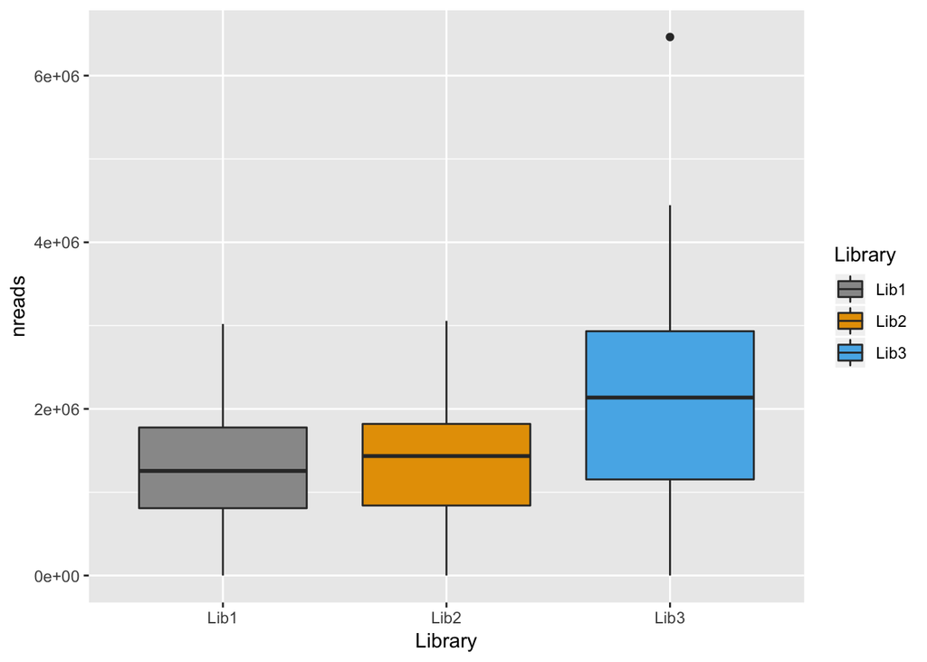

```r
# Crear paleta apta para daltónicos:
cbPalette <- c("#999999", "#E69F00", "#56B4E9", "#009E73", "#F0E442", "#0072B2", "#D55E00", "#CC79A7")

# Usar paleta en gráfica:
p <- ggplot(data=reads, aes(x=Library, y=nreads, fill=Library)) + geom_boxplot()
p + scale_fill_manual(values=cbPalette)
```

**Usar una paleta de ColorBrewer**

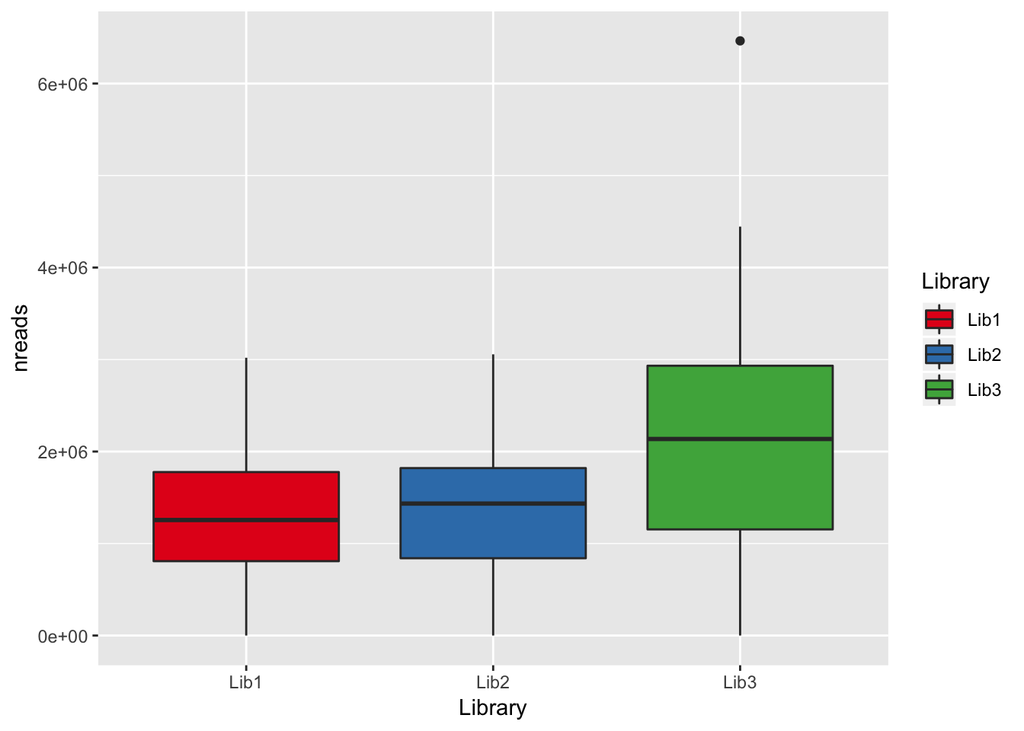

```r
p <- ggplot(data=reads, aes(x=Library, y=nreads, fill=Library)) + geom_boxplot()
p + scale_fill_brewer(palette="Set1")
```

**Utilizar gradientes de colores**

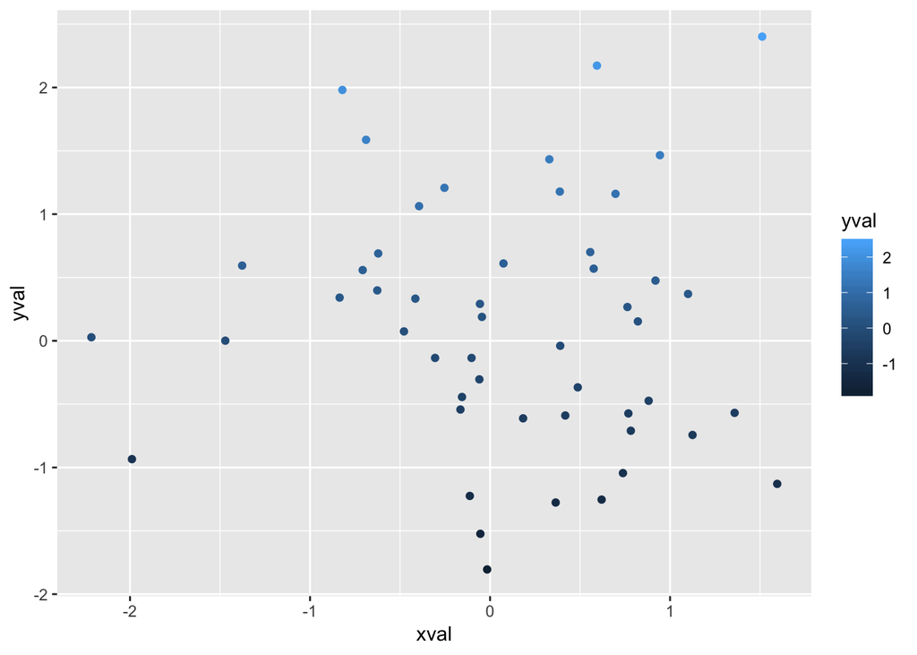

```r
# Generar datos
set.seed(1)
df <- data.frame(xval=rnorm(50), yval=rnorm(50))

# Plot
ggplot(df, aes(x=xval, y=yval, colour=yval)) + geom_point()
```

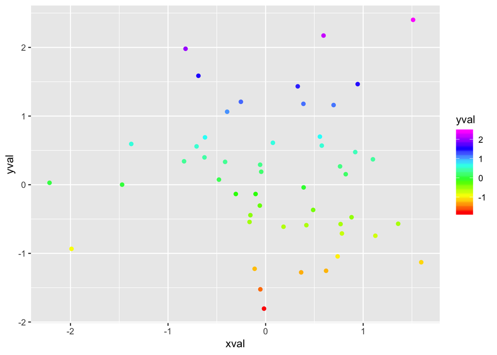

```r
# Cambiar gradiente
ggplot(df, aes(x=xval, y=yval, colour=yval)) + geom_point() +
    scale_colour_gradientn(colours=rainbow(6))
```

### Múltiples gráficas (=/= facets) en una gráfica:

Veamos este [ejemplo de R Cookbook](http://www.cookbook-r.com/Graphs/Multiple_graphs_on_one_page_%28ggplot2%29/) sobre mutlipltos:

Primero generamos y guardamos en objetos 4 gráficas:

```r
# This example uses the ChickWeight dataset, which comes with ggplot2
# First plot
p1 <- ggplot(ChickWeight, aes(x=Time, y=weight, colour=Diet, group=Chick)) +
    geom_line() +
    ggtitle("Growth curve for individual chicks")

# Second plot
p2 <- ggplot(ChickWeight, aes(x=Time, y=weight, colour=Diet)) +
    geom_point(alpha=.3) +
    geom_smooth(alpha=.2, size=1) +
    ggtitle("Fitted growth curve per diet")

# Third plot
p3 <- ggplot(subset(ChickWeight, Time==21), aes(x=weight, colour=Diet)) +
    geom_density() +
    ggtitle("Final weight, by diet")

# Fourth plot
p4 <- ggplot(subset(ChickWeight, Time==21), aes(x=weight, fill=Diet)) +
    geom_histogram(colour="black", binwidth=50) +
    facet_grid(Diet ~ .) +
    ggtitle("Final weight, by diet") +
    theme(legend.position="none")        # No legend (redundant in this graph)
```

Luego las graficamos juntas con la función `multiplot`, del paquete Rmisc:

```r
library(Rmisc)
```

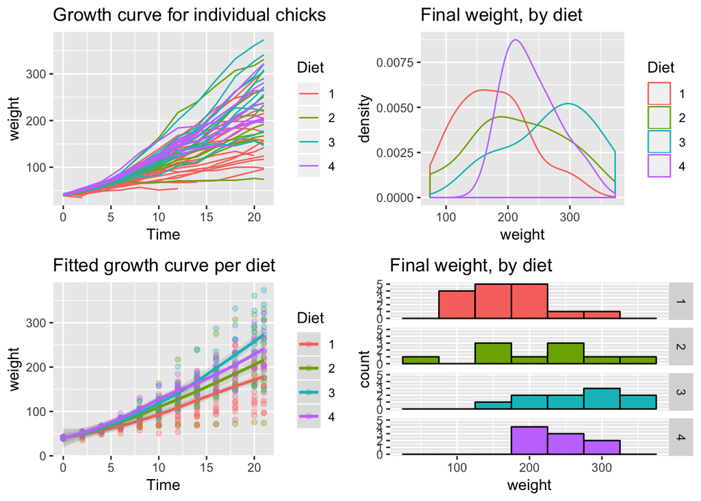

```r
multiplot(p1, p2, p3, p4, cols=2)
```

## Graficar árboles filogenéticos

La graficación de árboles filogenéticos se hace con el paquete `ape`, con el paquete `phytools` para funcionalidad extendida. No lo veremos en este curso, pero les dejo bibliografía recomendada:

- [Phylogenetic trees in R, del blog Sensory Evolution](https://ecomorph.wordpress.com/2014/10/09/phylogenetic-trees-in-r-4/)
- [Blog de phytools](http://blog.phytools.org/)
- [Documentación de ggtree](https://www.bioconductor.org/packages/3.3/bioc/vignettes/ggtree/inst/doc/treeVisualization.html)

Los árboles filogenéticos también pueden graficarse estilo ggplot, con el paquete de Biocounductor [ggtree](https://bioconductor.org/packages/release/bioc/html/ggtree.html).